# Decision Trees and Ensemble Models

Contains material from:

- Michael Bowles, *Machine Learning in Python*, Wiley, 2015.
- Trevor Hastie, Robert Tibshirani, and Jerome Friedman, *The Elements of Statistical Learning: Data Mining, Inference, and Prediction*, Springer, 2009.
- G. James, D. Witten, T. Hastie and R. Tibshirani, *An Introduction to Statistical Learning, with applications in R*, Springer, 2013.
- The scikit-learn tutorial and user guide at http://scikit-learn.org/.

> Panos Louridas, Associate Professor  
> Department of Management Science and Technology  
> Athens University of Economics and Business  
> louridas@aueb.gr

# Predict Wine Quality

- As a motivational example, we'll use a decision tree to predict the quality of wine.
- Our dataset will consist of of red wine samples from the north of Portugal.
- We'll use pandas to read it.

```python
import pandas as pd

import requests

wine_data_url = 'http://mlr.cs.umass.edu/ml/machine-learning-databases/wine-quality/winequality-red.csv'

wine_df = pd.read_csv(wine_data_url, sep=";")
wine_df[:10]
```

|  | fixed acidity | volatile acidity | citric acid | residual sugar | chlorides | free sulfur dioxide | total sulfur dioxide | density | pH | sulphates | alcohol | quality |
| --- | --- | --- | --- | --- | --- | --- | --- | --- | --- | --- | --- | --- |
| 0 | 7.4 | 0.70 | 0.00 | 1.9 | 0.076 | 11.0 | 34.0 | 0.9978 | 3.51 | 0.56 | 9.4 | 5 |
| 1 | 7.8 | 0.88 | 0.00 | 2.6 | 0.098 | 25.0 | 67.0 | 0.9968 | 3.20 | 0.68 | 9.8 | 5 |
| 2 | 7.8 | 0.76 | 0.04 | 2.3 | 0.092 | 15.0 | 54.0 | 0.9970 | 3.26 | 0.65 | 9.8 | 5 |
| 3 | 11.2 | 0.28 | 0.56 | 1.9 | 0.075 | 17.0 | 60.0 | 0.9980 | 3.16 | 0.58 | 9.8 | 6 |
| 4 | 7.4 | 0.70 | 0.00 | 1.9 | 0.076 | 11.0 | 34.0 | 0.9978 | 3.51 | 0.56 | 9.4 | 5 |
| 5 | 7.4 | 0.66 | 0.00 | 1.8 | 0.075 | 13.0 | 40.0 | 0.9978 | 3.51 | 0.56 | 9.4 | 5 |
| 6 | 7.9 | 0.60 | 0.06 | 1.6 | 0.069 | 15.0 | 59.0 | 0.9964 | 3.30 | 0.46 | 9.4 | 5 |
| 7 | 7.3 | 0.65 | 0.00 | 1.2 | 0.065 | 15.0 | 21.0 | 0.9946 | 3.39 | 0.47 | 10.0 | 7 |
| 8 | 7.8 | 0.58 | 0.02 | 2.0 | 0.073 | 9.0 | 18.0 | 0.9968 | 3.36 | 0.57 | 9.5 | 7 |
| 9 | 7.5 | 0.50 | 0.36 | 6.1 | 0.071 | 17.0 | 102.0 | 0.9978 | 3.35 | 0.80 | 10.5 | 5 |

- Our features will be the different columns apart from `quality`, which is our target.
- Our task involves *regression*.
- We want to predict the *value* of a numerical target.
- To this purpose we'll use `DecisionTreeRegressor`.

```python
from sklearn.tree import DecisionTreeRegressor

wine_tree = DecisionTreeRegressor(max_depth=3)

wine_tree.fit(wine_df.loc[:, 'fixed acidity':'alcohol'], wine_df['quality'])
```

```
DecisionTreeRegressor(criterion='mse', max_depth=3, max_features=None,
           max_leaf_nodes=None, min_impurity_split=1e-07,
           min_samples_leaf=1, min_samples_split=2,
           min_weight_fraction_leaf=0.0, presort=False, random_state=None,
           splitter='best')
```

- To understand what happened we should draw the resulting decision tree.
- We need to install GraphViz and its Python interface, `pydotplus`.

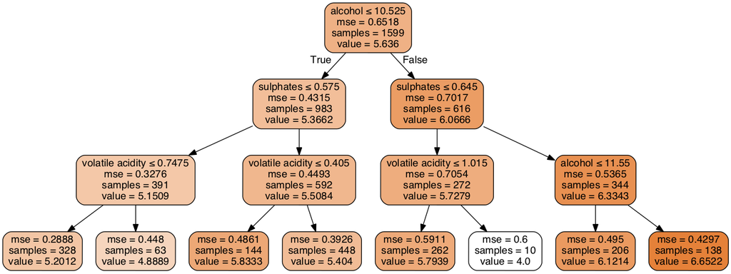

```python
from sklearn import tree

from sklearn.externals.six import StringIO
from IPython.display import Image
import pydotplus

dot_data = StringIO()
tree.export_graphviz(wine_tree, out_file=dot_data,
                     feature_names=wine_df.columns[:-1],
                     filled=True, rounded=True,
                     special_characters=True)
graph = pydotplus.graph_from_dot_data(dot_data.getvalue())
Image(graph.create_png())
```

# A Regression Decision Tree on Synthetic Data.

- To see how decision trees actually work, we'll work with a synthetic dataset.
- In particular, we'll build a simple data set with `y = x + random`.
- We'll have 100 samples, from -0.5 to +0.5.

```python
import numpy as np

x = np.linspace(-.5, .5, 100)
```

- scikit-learn expects the training data to be in an array of dimensions `n_samples`, `n_features`.
- Here we have `n_features = 1` (since each sample consists of just one value).
- We'll use `xs` to represent the training data in the form that scikit-learn expects.

```python
xs = x.reshape(x.shape[0], 1)
print(xs[:10])
```

```
[[-0.5       ]
 [-0.48989899]
 [-0.47979798]
 [-0.46969697]
 [-0.45959596]
 [-0.44949495]
 [-0.43939394]
 [-0.42929293]
 [-0.41919192]
 [-0.40909091]]
```

- Now we'll generate the `y` values.
- Remember, we are talking about *synthetic* data.

```python
np.random.seed(1)
y = x + np.random.normal(loc=0, scale=0.1, size=x.shape[0])
print(y[:10])
```

```
[-0.33756546 -0.55107463 -0.53261516 -0.57699383 -0.3730552  -0.67964882
 -0.26491276 -0.50541362 -0.38728801 -0.43402795]
```

- Let's plot the data to see what we've got.

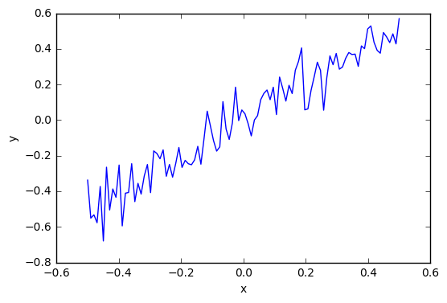

```python
import matplotlib.pyplot as plt

%matplotlib inline

plt.plot(x, y)
plt.xlabel('x')
plt.ylabel('y')
```

- We'll try to fit the data with a binary decision tree, in particular a `DecisionTreeRegressor`.

```python
simple_tree = DecisionTreeRegressor(max_depth=1)
simple_tree.fit(xs, y)
```

```
DecisionTreeRegressor(criterion='mse', max_depth=1, max_features=None,
           max_leaf_nodes=None, min_impurity_split=1e-07,
           min_samples_leaf=1, min_samples_split=2,
           min_weight_fraction_leaf=0.0, presort=False, random_state=None,
           splitter='best')
```

- We have specified that the decision tree will have a maximum depth of 1.
- That means that we'll create a decision tree that will pick a value of `x`, called *split point* that will separate the dataset into two subsets.

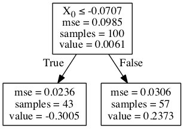

```python
dot_data = StringIO()
tree.export_graphviz(simple_tree, out_file=dot_data,
                     special_characters=True)
graph = pydotplus.graph_from_dot_data(dot_data.getvalue())
Image(graph.create_png())
```

- How is the split point selected?
- We try every possible split point.
- For each pair of data subsets resulting from the split, we calculate the *variance reduction*.
- If the original set is $S$ and we have two subsets $S_A$ and $S_B$, the variance reduction is:

$$ \operatorname{Var}(S) - (\operatorname{Var}(S_A) + \operatorname{Var}(S_B))$$

- We select the split that gives two subsets $S_A$ and $S_B$ with the greatest variance reduction.
- This is determined by the *mean squared error* (mse in the tree).
- In this particular example, we have just one feature. If we had more than one feature, the decision tree will try all features and pick the best feature with the best split.
- The value attribute of each node is the predicted value for the subset in the node.
- Therefore we can plot the result of the regression tree, by predicting the value for the set of possible `x` values.

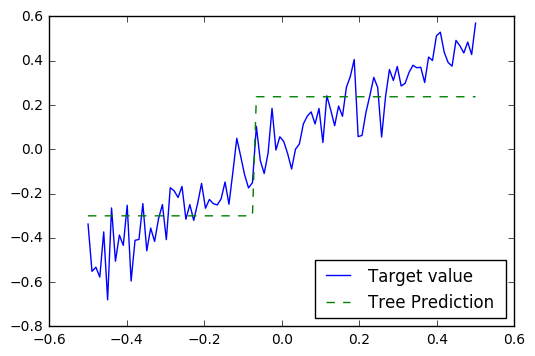

```python
y_pred  = simple_tree.predict(xs)
plt.plot(x, y, label='Target value')
plt.plot(x, y_pred, label='Tree Prediction ', linestyle='--')
plt.legend(loc=4)
```

- We see that we got a step function.
- Let's see what happens if we increase the level of the decision tree by one.
- We create a new `DecisionTreeRegressor` with a `max_depth` of 2.

```python
simple_tree_2 = DecisionTreeRegressor(max_depth=2)
simple_tree_2.fit(xs, y)
```

```
DecisionTreeRegressor(criterion='mse', max_depth=2, max_features=None,
           max_leaf_nodes=None, min_impurity_split=1e-07,
           min_samples_leaf=1, min_samples_split=2,
           min_weight_fraction_leaf=0.0, presort=False, random_state=None,
           splitter='best')
```

- And then we plot the resulting tree.

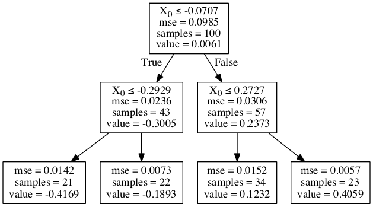

```python
dot_data = StringIO()
tree.export_graphviz(simple_tree_2, out_file=dot_data,
                     special_characters=True)
graph = pydotplus.graph_from_dot_data(dot_data.getvalue())
Image(graph.create_png())
```

- We can, again, plot the predictions against the actual values.
- We see that the predictions follow the values more closely.

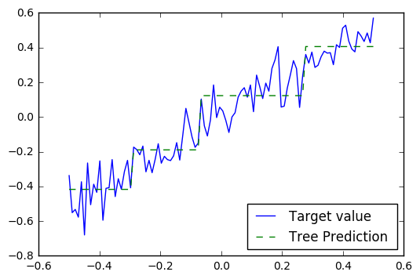

```python
y_pred  = simple_tree_2.predict(xs)
plt.plot(x, y, label='Target value')
plt.plot(x, y_pred, label='Tree Prediction ', linestyle='--')
plt.legend(loc=4)
```

- Is there a limit to how well we can predict by increasing the number of levels?
- We can get some insight by trying different `max_depth` values and running k-fold validation to get the scores.

```python
from sklearn.model_selection import cross_val_score, KFold

from scipy.stats import sem

all_depths = []
all_mean_scores = []
for max_depth in range(1, 11):
    all_depths.append(max_depth)
    simple_tree = DecisionTreeRegressor(max_depth=max_depth)
    cv = KFold(n_splits=5, shuffle=True, random_state=13)
    scores = cross_val_score(simple_tree, xs, y, cv=cv)
    mean_score = np.mean(scores)
    all_mean_scores.append(np.mean(scores))
    print("max_depth = ", max_depth, scores, mean_score, sem(scores))
```

```
max_depth =  1 [ 0.60749529  0.76553666  0.68168224  0.65461799  0.64686273] 0.67123898167 0.0263958622842
max_depth =  2 [ 0.82158513  0.93272444  0.80619343  0.86045269  0.79812999] 0.843817133854 0.0246762758708
max_depth =  3 [ 0.89646992  0.94990152  0.76082515  0.89045479  0.90167658] 0.879865593085 0.0315746823047
max_depth =  4 [ 0.87180508  0.94195734  0.75367326  0.84602681  0.89616463] 0.861925426083 0.0313419335153
max_depth =  5 [ 0.83065327  0.91484886  0.63049044  0.84090419  0.8896302 ] 0.82130539433 0.0501500253117
max_depth =  6 [ 0.82796356  0.92630249  0.6404988   0.82894716  0.9040183 ] 0.825546061363 0.0502840180056
max_depth =  7 [ 0.82689692  0.91979719  0.62939832  0.83111896  0.8957964 ] 0.820601557649 0.0510896093781
max_depth =  8 [ 0.84304415  0.917409    0.6229448   0.82849293  0.89829753] 0.822037682877 0.0524557761938
max_depth =  9 [ 0.83755113  0.9161887   0.6229448   0.82766507  0.90459625] 0.821789191664 0.0527211209494
max_depth =  10 [ 0.84374178  0.9165974   0.6229448   0.82817977  0.90442154] 0.823177059633 0.052853059246
```

- The best result is at `max_depth=3`.

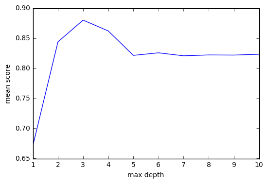

```python
plt.plot(all_depths, all_mean_scores, label='True y')
plt.xlabel('max depth')
plt.ylabel('mean score')
```

- Of course, in reality we would just use `GridSearchCV` to do that.

```python
from sklearn.model_selection import GridSearchCV


parameters = [
  {'max_depth': list(range(1, 11))},
 ]

clf = GridSearchCV(DecisionTreeRegressor(), parameters, cv=5)

clf = clf.fit(xs, y)
print(clf.best_estimator_)
print(clf.best_params_)
```

```
DecisionTreeRegressor(criterion='mse', max_depth=5, max_features=None,
           max_leaf_nodes=None, min_impurity_split=1e-07,
           min_samples_leaf=1, min_samples_split=2,
           min_weight_fraction_leaf=0.0, presort=False, random_state=None,
           splitter='best')
{'max_depth': 5}
```

- Let's see where the problem with high `max_depth` values comes from.
- We'll plot the results again for `max_depth=10`.

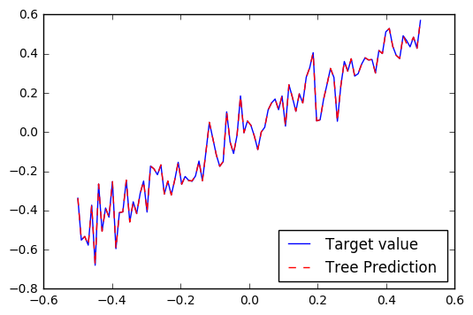

```python
simple_tree_10 = DecisionTreeRegressor(max_depth=10)
simple_tree_10.fit(xs, y)
y_pred  = simple_tree_10.predict(xs)
plt.plot(x, y, label='Target value')
plt.plot(x, y_pred, label='Tree Prediction ', linestyle='--', color='r')
plt.legend(loc=4)
```

- As you can see the predicted value almost entirely coincides with the target value.
- That is an instance of *overfitting*.
- In fact, the situation is even worse.
- Remember, we are working with *synthetic* data.
- We know what the true values of `y` are: they are `y = x`.
- So we can calculate the error regarding *the real values of y* (something we can do only with synthetic data).

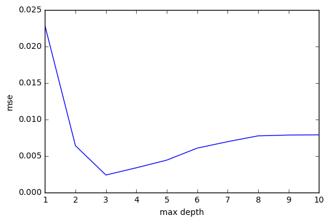

```python
from sklearn.metrics import mean_squared_error

all_depths = []
all_mses = []
y_true = x

for max_depth in range(1, 11):
    all_depths.append(max_depth)
    simple_tree = DecisionTreeRegressor(max_depth=max_depth)
    simple_tree.fit(xs, y)
    y_pred  = simple_tree.predict(xs)
    mse = mean_squared_error(y_true, y_pred)
    all_mses.append(np.mean(mse))

plt.plot(all_depths, all_mses, label='True y')
plt.xlabel('max depth')
plt.ylabel('mse')
```

# Decision Tree Classification

- `DecisionTreeClassifier` is a class capable of performing multi-class classification on a dataset.
- As with other classifiers, `DecisionTreeClassifier` takes as input two arrays: an array `X`, sparse or dense, of size `[n_samples, n_features]` holding the training samples, and an array `Y` of integer values, size `[n_samples]`, holding the class labels for the training samples.

```python
from sklearn.datasets import load_iris
from sklearn.tree import DecisionTreeClassifier

iris = load_iris()
clf = tree.DecisionTreeClassifier()
clf = clf.fit(iris.data, iris.target)
clf
```

```
DecisionTreeClassifier(class_weight=None, criterion='gini', max_depth=None,
            max_features=None, max_leaf_nodes=None,
            min_impurity_split=1e-07, min_samples_leaf=1,
            min_samples_split=2, min_weight_fraction_leaf=0.0,
            presort=False, random_state=None, splitter='best')
```

- We have not given a `max_depth`, so nodes are expanded until all leaves are pure or until all leaves contain less than `min_samples_split` samples.

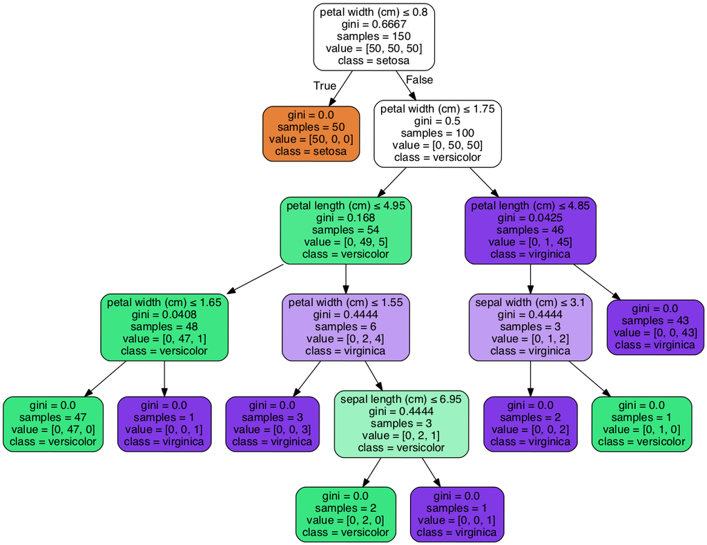

```python
dot_data = StringIO()
tree.export_graphviz(clf, out_file=dot_data,
                     feature_names=iris.feature_names,
                     class_names=iris.target_names,
                     filled=True, rounded=True,
                     special_characters=True)
graph = pydotplus.graph_from_dot_data(dot_data.getvalue())
Image(graph.create_png())
```

- In classification trees, scikit-learn can use one of two criteria for the split:
  - `gini`, measuring Gini impurity (not to be confused with the Gini coefficient).
  - `entropy`, measuring the information gain.
- The Gini impurity can be computed by summing the probability $f_i$ of each item being chosen times the probability $1-f_i$ of a mistake in categorizing that item.
- It reaches its minimum (zero) when all cases in the node fall into a single target category.
- To compute the Gini impurity for a set of items, suppose $i \in \{1, 2, ..., m\}$, and let $f_i$ be the fraction of items labeled with value $i$ in the set. Then we have: $$I_{G}(f) = \sum_{i=1}^{m} f_i (1-f_i) = \sum_{i=1}^{m} (f_i - {f_i}^2) = \sum_{i=1}^m f_i - \sum_{i=1}^{m} {f_i}^2 = 1 - \sum^{m}_{i=1} {f_i}^{2} = \sum_{i\neq k}f_i f_k$$
- We calculate the Gini impurity for each possible split and we select the split that results to the least Gini impurity.
- As an aside:
- The Gini coefficient (also known as the Gini index or Gini ratio) is a measure of statistical dispersion intended to represent the income distribution of a nation's residents, and is the most commonly used measure of inequality.
- It was developed by the Italian statistician and sociologist Corrado Gini and published in his 1912 paper "Variability and Mutability" (Italian: Variabilità e mutabilità).
- The Gini index measures the extent to which the distribution of income among individuals or households within an economy deviates from a perfectly equal distribution.
- A Lorenz curve plots the cumulative percentages of total income received against the cumulative number of recipients, starting with the poorest individual or household.
- The Gini index measures the area between the Lorenz curve and a hypothetical line of absolute equality, expressed as a percentage of the maximum area under the line.
- Thus a Gini index of 0 represents perfect equality, while an index of 100 implies perfect inequality.
- In the figure below, if $G$ is the Gini coefficient we have $G = A / (A + B)$.

Source: [World Bank](http://data.worldbank.org/indicator/SI.POV.GINI).

[figure not shown]

- The *information gain* is the change in the information entropy that results from partitioning the items.

\begin{align} G(X, a) & = H(X) - \Big[p_1 H(n_1) + p_2 H(n_2) + \cdots + p_m H(n_m)\Big]\\ & = H(X) - p_1 H(n_1) - p_2 H(n_2) - \cdots - p_m H(n_m) \end{align}

- In this formula, $X$ is the node that we want to partition, $n_1, n_2, \ldots n_m$ are the children nodes, $H(X)$ or $H(n_i)$ is the entropy in the node.
- The entropy of a node is defined as:

\begin{align} H(X) & = -\,p(x_1) \lg p(x_1) - p(x_2) \lg p(x_2) - \cdots - p(x_n) \lg p(x_n)\\ & = - \Big[p(x_1) \lg p(x_1) + p(x_2) \lg p(x_2) + \cdots + p(x_n) \lg p(x_n)\Big]\\ \end{align}

- In the above, $x_i$ is the event that an item belongs in the class $i$.
- Back to our example, after being fitted, the model can then be used to predict the class of samples.

```python
iris.target_names[clf.predict(iris.data[:1, :])]
```

```
array(['setosa'],
      dtype='<U10')
```

- Alternatively, the probability of each class can be predicted, which is the fraction of training samples of the same class in a leaf.

```python
clf.predict_proba(iris.data[:1, :])
```

```
array([[ 1.,  0.,  0.]])
```

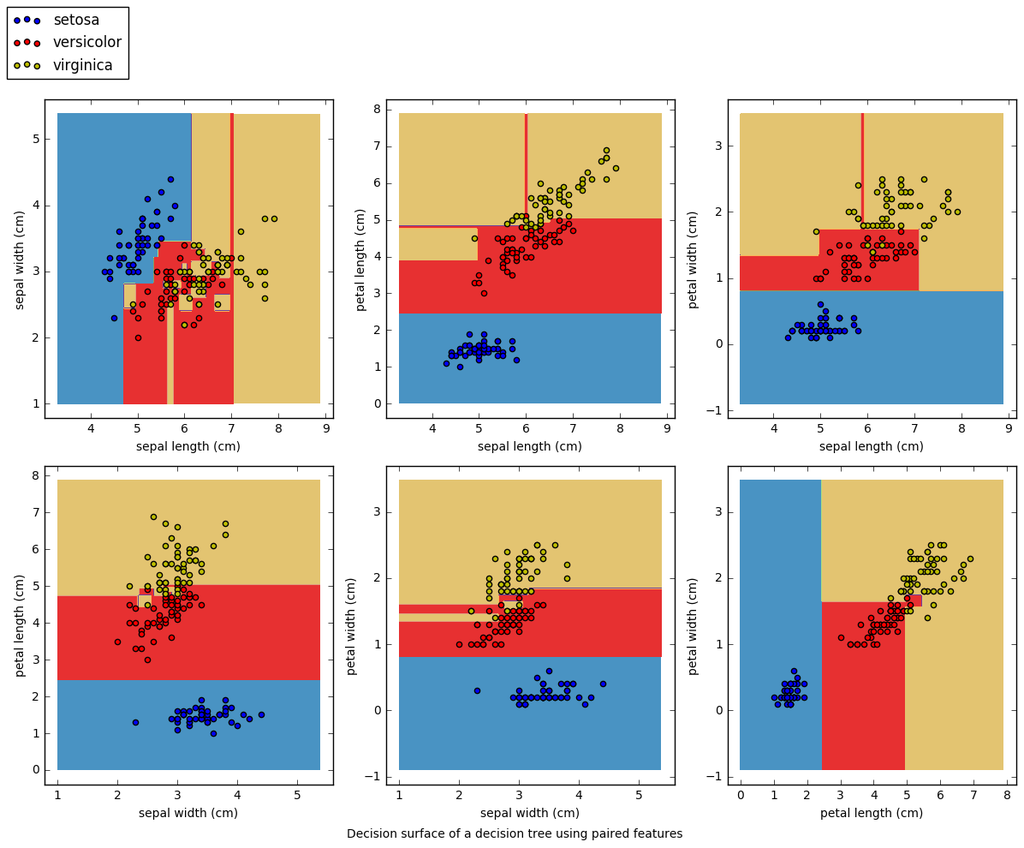

```python
n_classes = 3
plot_colors = "bry"
plot_step = 0.02

# Load data
iris = load_iris()

plt.figure(figsize=(12, 10))

for pairidx, pair in enumerate([[0, 1], [0, 2], [0, 3],
                                [1, 2], [1, 3], [2, 3]]):
    # We only take the two corresponding features
    X = iris.data[:, pair]
    y = iris.target

    # Train
    clf = DecisionTreeClassifier().fit(X, y)

    # Plot the decision boundary
    plt.subplot(2, 3, pairidx + 1)

    x_min, x_max = X[:, 0].min() - 1, X[:, 0].max() + 1
    y_min, y_max = X[:, 1].min() - 1, X[:, 1].max() + 1
    xx, yy = np.meshgrid(np.arange(x_min, x_max, plot_step),
                         np.arange(y_min, y_max, plot_step))

    Z = clf.predict(np.c_[xx.ravel(), yy.ravel()])
    Z = Z.reshape(xx.shape)
    cs = plt.contourf(xx, yy, Z, cmap=plt.cm.Paired)

    plt.xlabel(iris.feature_names[pair[0]])
    plt.ylabel(iris.feature_names[pair[1]])
    plt.axis("tight")

    # Plot the training points
    for i, color in zip(range(n_classes), plot_colors):
        idx = np.where(y == i)
        plt.scatter(X[idx, 0], X[idx, 1], c=color, label=iris.target_names[i],
                    cmap=plt.cm.Paired)

    plt.axis("tight")

plt.suptitle("Decision surface of a decision tree using paired features",
             position=(0.5, 0.035))
handles, labels = plt.gca().get_legend_handles_labels()
plt.figlegend(handles=handles, labels=labels, loc='upper left')
plt.tight_layout(rect=[0, 0.03, 1, 0.9])
```

# Measuring the Quality of Fit

- In a regression setting, the most commonly-used measure of the quality of fit is the *mean squared error* (MSE): $$ \operatorname{MSE} = \frac{1}{n}\sum_{i = 1}^{n}(y_i - \hat{f}(x_i))^2$$
- $\hat{f}(x_i)$ is the prediction that $\hat{f}$ gives for the $i$th observation.
- The MSE will be small if the predicted responses are very close to the true responses, and will be large if for some of the observations, the predicted and true responses differ substantially.

[figure not shown]

- Left: Data simulated from $f$, shown in black. Three estimates of $f$ are shown: the linear regression line (orange curve), and two smoothing spline fits (blue and green curves).
- Right: Training MSE (grey curve), test MSE (red curve), and minimum possible test MSE over all methods (dashed line). Squares represent the training and test MSEs for the three fits shown in the left-hand panel.

Figure taken from "An Introduction to Statistical Learning, with applications in R" (Springer, 2013) with permission from the authors: G. James, D. Witten, T. Hastie and R. Tibshirani.

[figure not shown]

- Similar figure, using a different $f$ that is much closer to linear. In this setting, linear regression provides a very good fit to the data.

Figure taken from "An Introduction to Statistical Learning, with applications in R" (Springer, 2013) with permission from the authors: G. James, D. Witten, T. Hastie and R. Tibshirani.

- In the right-hand panel of the previous figure, as the flexibility of the statistical learning method increases, we observe a monotone decrease in the training MSE and a U-shape in the test MSE.
- This is a fundamental property of statistical learning that holds regardless of the particular data set at hand and regardless of the statistical method being used.
- As model flexibility increases, training MSE will decrease, but the test MSE may not.
- When a given method yields a small training MSE but a large test MSE, we are said to be *overfitting* the data.
- This happens because our statistical learning procedure is working too hard to find patterns in the training data, and may be picking up some patterns that are just caused by random chance rather than by true properties of the unknown function $f$.

[figure not shown]

- Similar figure, but here $f$ is highly non-linear. The training and test MSE curves still exhibit the same general patterns, but now there is a rapid decrease in both curves before the test MSE starts to increase slowly.

Figure taken from "An Introduction to Statistical Learning, with applications in R" (Springer, 2013) with permission from the authors: G. James, D. Witten, T. Hastie and R. Tibshirani.

# The Bias-Variance Trade-Off

- The U-shape observed in the test MSE curves turns out to be the result of two competing properties of statistical learning methods.
- It is possible to show that the expected test MSE, for a given value $x_0$, can always be decomposed into the sum of three fundamental quantities:
  - the variance of $\hat{f}(x_0)$
  - the squared bias of $\hat{f}(x_0)$
  - the variance of the error terms $\epsilon$

$$ E\left(y_0 - \hat{f}(x_0)\right)^2 = \operatorname{Var}(\hat{f}(x_0)) + [\operatorname{Bias}(\hat{f}(x_0))]^2 + \operatorname{Var}(\epsilon)$$

- The notation $E\left(y_0 - \hat{f}(x_0)\right)^2$ defines the *expected test MSE* and refers to the average test MSE that we would obtain if we repeatedly estimated $f$ using a large number of training sets, and tested each at $x_0$.
- The overall expected test MSE can be computed by averaging $E\left(y_0 - \hat{f}(x_0)\right)^2$ over all possible values of $x_0$ in the test set.
- The previous equation tells us that in order to minimize the expected test error, we need to select a statistical learning method that simultaneously achieves low variance and low bias.
- Note that variance is inherently a nonnegative quantity, and squared bias is also nonnegative.
- Hence, we see that the expected test MSE can never lie below $\operatorname{Var}(\epsilon)$, the irreducible error.
- Variance refers to the amount by which $\hat{f}$ would change if we estimated it using a different training data set.
- Since the training data are used to fit the statistical learning method, different training data sets will result in a different $\hat{f}$.
- But ideally the estimate for $f$ should not vary too much between training sets.
- However, if a method has high variance then small changes in the training data can result in large changes in $\hat{f}$.
- In general, more flexible statistical methods have higher variance.
- On the other hand, bias refers to the error that is introduced by approximating a real-life problem, which may be extremely complicated, by a much simpler model.
- For example, linear regression assumes that there is a linear relationship between $Y$ and $X_1$, $X_2$, $\ldots$, $X_p$.
- It is unlikely that any real-life problem truly has such a simple linear relationship, and so performing linear regression will undoubtedly result in some bias in the estimate of $f$.
- Generally, more flexible methods result in less bias.
- As a general rule, as we use more flexible methods, the variance will increase and the bias will decrease.
- The relative rate of change of these two quantities determines whether the test MSE increases or decreases.
- As we increase the flexibility of a class of methods, the bias tends to initially decrease faster than the variance increases.
- Consequently, the expected test MSE declines. However, at some point increasing flexibility has little impact on the bias but starts to significantly increase the variance.
- When this happens the test MSE increases.

[figure not shown]

- Squared bias (blue curve), variance (orange curve), Var(ε) (dashed line), and test MSE (red curve) for the three datasets in the previous figures.
- The vertical dotted line indicates the flexibility level corresponding to the smallest test MSE.

Figure taken from "An Introduction to Statistical Learning, with applications in R" (Springer, 2013) with permission from the authors: G. James, D. Witten, T. Hastie and R. Tibshirani.

- The relationship between bias, variance, and test set MSE is referred to as the *bias-variance trade-off*.
- Good test set performance of a statistical learning method requires low variance as well as low squared bias.
- This is referred to as a trade-off because it is easy to obtain a method with extremely low bias but high variance (for instance, by drawing a curve that passes through every single training observation) or a method with very low variance but high bias (by fitting a horizontal line to the data).
- The challenge lies in finding a method for which both the variance and the squared bias are low.

# Improving Decision Trees

- Decision trees are simple to understand and to interpret. Trees can be visualised.
- Require little data preparation. Other techniques often require data normalisation, dummy variables need to be created and blank values to be removed.
- The cost of using the tree (i.e., predicting data) is logarithmic in the number of data points used to train the tree.
- They are able to handle both numerical and categorical data.
- Decision-tree learners can create over-complex trees that do not generalise the data well. This is an instance of overfitting.
- Decision trees can be unstable because small variations in the data might result in a completely different tree being generated.
- To overcome the disadvantages of decision trees, we aggregate them using *ensemble methods*.
- The goal of ensemble methods is to combine the predictions of several base estimators built with a given learning algorithm in order to improve generalizability / robustness over a single estimator.
- There are two kinds of ensemble methods:
  - In *averaging methods* , the driving principle is to build several estimators independently and then to average their predictions. On average, the combined estimator is usually better than any of the single base estimator because its variance is reduced.
  - In *boosting methods*, base estimators are built sequentially and one tries to reduce the bias of the combined estimator. The motivation is to combine several weak models to produce a powerful ensemble.
- One way to reduce the variance and hence increase the prediction accuracy of a statistical learning method is to take many training sets from the population, build a separate prediction model using each training set, and average the resulting predictions.
- In other words, we could calculate $\hat{f}^1(x)$, $\hat{f}^2(x)$, $\ldots$, $\hat{f}^{B}(x)$ using $B$ separate training sets, and average them in order to obtain a single low-variance statistical learning model:

$$ \hat{f}_{\textrm{avg}}(x) = \frac{1}{B}\sum_{b = 1}^{B}\hat{f}^b(x) $$

- Of course, this is not possible, because we do not have multiple datasets.
- Instead, we can apply *bootstrapping*.
- Bootstrapping is a general, and very powerful idea in statistics.
- We construct multiple datasets by *sampling with replacement* from our original dataset.

# Bagging

- In our trees, we will bootstrap by taking repeated samples from the (single) training data set.
- We therefore generate $B$ different bootstrapped training data sets.
- We then train our method on the $b$th bootstrapped training set in order to get $\hat{f}^{∗b}(x)$, and finally average all the predictions, to obtain:

$$ \hat{f}_{\textrm{bag}}(x) = \frac{1}{B}\sum_{b = 1}^{B}\hat{f}^{*b}(x) $$

- This is called *bagging*.
- Bagging can improve predictions for many regression methods, but it is particularly useful for decision trees.
- To apply bagging to regression trees, we simply construct $B$ regression trees using $B$ bootstrapped training sets, and average the resulting predictions.
- These trees are grown deep, and are not pruned.
- Hence each individual tree has high variance, but low bias. Averaging these $B$ trees reduces the variance.
- Bagging has been demonstrated to give impressive improvements in accuracy by combining together hundreds or even thousands of trees into a single procedure.
- Bagging can also be used in a classification problem where $Y$ is qualitative.
- In that situation, there are a few possible approaches, but the simplest is as follows.
- For a given test observation, we can record the class predicted by each of the $B$ trees, and take a majority vote: the overall prediction is the most commonly occurring majority class among the $B$ predictions.
- Bagging is implemented with the `sklearn.ensemble.BaggingRegressor` class.
- The class takes, as usual, many parameters that affect how bagging will be performed.
- One of them, `n_estimators`, specifies how many base estimators will be used in the ensemble.
- By default, `n_estimators=10`.

# Bagging with the Heart Data

- Let's take an example with real data.
- The dataset concerns people examined for the presence of heart disease.
- There are datasets for people in different locations; we'll use the dataset from Cleveland.
- The feature `num` indicates the presence (values 1,2,3,4) or absence (value 0) of heart disease.
- We'll read it again with pandas.

```python
heart_url = 'http://mlr.cs.umass.edu/ml/machine-learning-databases/heart-disease/processed.cleveland.data'

colnames = [
    "age",
    "sex",
    "cp",
    "trestbps",
    "chol",
    "fbs",
    "restecg",
    "thalach",
    "exang",
    "oldpeak",
    "slope",
    "ca",
    "thal",
    "num"
]

heart_df = pd.read_csv(heart_url, sep=",", names=colnames, na_values="?")
heart_df = heart_df.dropna()
heart_df['disease'] = np.where(heart_df['num'] == 0, 0, 1)
heart_df[:10]
```

|  | age | sex | cp | trestbps | chol | fbs | restecg | thalach | exang | oldpeak | slope | ca | thal | num | disease |
| --- | --- | --- | --- | --- | --- | --- | --- | --- | --- | --- | --- | --- | --- | --- | --- |
| 0 | 63.0 | 1.0 | 1.0 | 145.0 | 233.0 | 1.0 | 2.0 | 150.0 | 0.0 | 2.3 | 3.0 | 0.0 | 6.0 | 0 | 0 |
| 1 | 67.0 | 1.0 | 4.0 | 160.0 | 286.0 | 0.0 | 2.0 | 108.0 | 1.0 | 1.5 | 2.0 | 3.0 | 3.0 | 2 | 1 |
| 2 | 67.0 | 1.0 | 4.0 | 120.0 | 229.0 | 0.0 | 2.0 | 129.0 | 1.0 | 2.6 | 2.0 | 2.0 | 7.0 | 1 | 1 |
| 3 | 37.0 | 1.0 | 3.0 | 130.0 | 250.0 | 0.0 | 0.0 | 187.0 | 0.0 | 3.5 | 3.0 | 0.0 | 3.0 | 0 | 0 |
| 4 | 41.0 | 0.0 | 2.0 | 130.0 | 204.0 | 0.0 | 2.0 | 172.0 | 0.0 | 1.4 | 1.0 | 0.0 | 3.0 | 0 | 0 |
| 5 | 56.0 | 1.0 | 2.0 | 120.0 | 236.0 | 0.0 | 0.0 | 178.0 | 0.0 | 0.8 | 1.0 | 0.0 | 3.0 | 0 | 0 |
| 6 | 62.0 | 0.0 | 4.0 | 140.0 | 268.0 | 0.0 | 2.0 | 160.0 | 0.0 | 3.6 | 3.0 | 2.0 | 3.0 | 3 | 1 |
| 7 | 57.0 | 0.0 | 4.0 | 120.0 | 354.0 | 0.0 | 0.0 | 163.0 | 1.0 | 0.6 | 1.0 | 0.0 | 3.0 | 0 | 0 |
| 8 | 63.0 | 1.0 | 4.0 | 130.0 | 254.0 | 0.0 | 2.0 | 147.0 | 0.0 | 1.4 | 2.0 | 1.0 | 7.0 | 2 | 1 |
| 9 | 53.0 | 1.0 | 4.0 | 140.0 | 203.0 | 1.0 | 2.0 | 155.0 | 1.0 | 3.1 | 3.0 | 0.0 | 7.0 | 1 | 1 |

- Now we'll run a `DecisionTreeClassifier` *and* a `BaggingClassifier` and compare their results.
- The `BaggingClasssifier` takes, among other parameters, the number of estimators (trees) that will be used and the number of jobs to run in parallel. If `n_jobs=-1` we'll have as many jobs as processors in parallel.

```python
from sklearn.ensemble import BaggingClassifier

from scipy.stats import sem


heart_tree = DecisionTreeClassifier(random_state=0)
cv_score = cross_val_score(heart_tree,
                           heart_df.loc[:, 'age':'thal'],
                           heart_df['disease'], cv=10)

print(np.mean(cv_score), sem(cv_score))

bagging_heart_tree = BaggingClassifier(DecisionTreeClassifier(random_state=0), n_estimators=50, n_jobs=-1)
bagged_cv_score = cross_val_score(bagging_heart_tree,
                                  heart_df.loc[:, 'age':'thal'],
                                  heart_df['disease'], cv=10)

print(np.mean(bagged_cv_score), sem(bagged_cv_score))
```

```
0.74724137931 0.0198476678434
0.811379310345 0.0303773433515
```

# Out-of-Bag Error Estimation

- There is another way to estimate the test error of a bagged model, without the need for cross-validation.
- It can be shown that, on average, each bagged tree uses about 2/3 of the observations.
- The remaining 1/3 of the observations not used to fit a given bagged tree are referred to as the *out-of-bag* (OOB) observations.
- Therefore, we can predict the response for the $i$th observation using each of the trees in which that observation was OOB.
- This will yield around $B/3$ predictions for the ith observation, where $B$ is the number of bootstrapped training sets.
- To get a single prediction for the $i$th observation, we can average these predicted responses (in regression trees) or can take a majority vote (in classification trees).
- So we get a single prediction for the $i$th observation; we do the same for all $n$ observations. In this way we can get an overall error estimate.
- In scikit-learn, we can specify that we want to use the OOB estimate during construction.
- Then we can get it after the fit.

```python
bagging_heart_tree = BaggingClassifier(DecisionTreeClassifier(random_state=0),
                                      n_estimators=50,
                                      oob_score=True,
                                      n_jobs=-1)

bagging_heart_tree.fit(heart_df.loc[:, 'age':'thal'],
                       heart_df['disease'])

bagging_heart_tree.oob_score_
```

```
0.7912457912457912
```

# Random Forests and Extremely Randomized Trees

- Random forests are an improvement over bagged trees.
- As in bagging, we build a number of decision trees on bootstrapped training samples.
- However, when building these decision trees, each time a split in a tree is considered, a *random sample of $m$ predictors* is chosen as split candidates from the full set of $p$ predictors.
- The split is allowed to take place using only these $m$ predictors.
- Usually we pick $m \approx \sqrt{p}$.
- The idea behind random forests is to *decorrelate* the trees.
- If there is a very strong predictor in the data set, then in the collection of bagged trees, all the trees will use that predictor for their top split.
- Therefore all the bagged trees will look similar and the predictions given by the individual trees will be highly correlated.
- However, we want to have uncorrelated quantities to achieve a reduction in variance.

```python
from sklearn.ensemble import RandomForestClassifier

forest = RandomForestClassifier(n_estimators=50, max_depth=None,
                                min_samples_split=2, random_state=0)
scores = cross_val_score(forest, heart_df.loc[:, 'age':'thal'], heart_df['disease'])
scores.mean()
```

```
0.83160448017590871
```

- In extremely randomized trees, randomness goes one step further in the way splits are computed.
- As in random forests, a random subset of candidate features is used.
- However, instead of looking for the most discriminative thresholds, thresholds are drawn at random for each candidate feature and the best of these randomly-generated thresholds is picked as the splitting rule.
- This usually allows to reduce the variance of the model a bit more, at the expense of a slightly greater increase in bias.
- Extremely randomized trees are implemented with the `ExtraTreesClassifier` and `ExtraTreesRegressor` classes.

```python
from sklearn.ensemble import ExtraTreesClassifier

extremely_rts = ExtraTreesClassifier(n_estimators=50,
                                     max_depth=None,
                                     min_samples_split=2,
                                     random_state=0)

scores = cross_val_score(extremely_rts, heart_df.loc[:, 'age':'thal'], heart_df['disease'])
scores.mean()
```

```
0.79446162303305157
```

- Improvements such as random forests, extremely randomized trees, and bagging typically result in improved accuracy over prediction using a single tree.
- Unfortunately, however, it can be difficult to interpret the resulting model.
- Recall that one of the advantages of decision trees is the attractive and easily interpreted tree diagram that can be produced.
- However, when we use a set of trees, it is no longer possible to represent the resulting statistical learning procedure using a single tree.
- It is no longer clear which variables are most important to the procedure.
- Thus, the improved models improves prediction accuracy at the expense of interpretability.
- We can obtain an overall summary of the importance of each predictor in ensemble models using the RSS (for ensemble regression trees) or the Gini index (for ensemble classification trees).
- In the case of ensemble regression trees, we can record the total amount that the RSS is decreased due to splits over a given predictor, averaged over all trees. A large value indicates an important predictor.
- Similarly, in the context of bagging classification trees, we can add up the total amount that the Gini index is decreased by splits over a given predictor, averaged over all trees.

```
1. feature 9 oldpeak (0.129569)
2. feature 12 thal (0.124776)
3. feature 11 ca (0.123218)
4. feature 7 thalach (0.111893)
5. feature 2 cp (0.108924)
6. feature 0 age (0.091370)
7. feature 4 chol (0.082918)
8. feature 3 trestbps (0.065285)
9. feature 8 exang (0.056351)
10. feature 10 slope (0.042605)
11. feature 1 sex (0.034237)
12. feature 6 restecg (0.019319)
13. feature 5 fbs (0.009534)
```

```
(-1, 13)
```

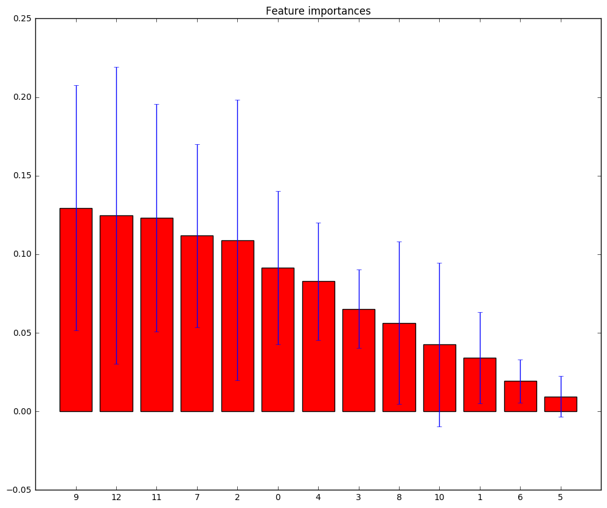

```python
X = heart_df.loc[:, 'age':'thal']
y =  heart_df['disease']

forest.fit(X, y)
importances = forest.feature_importances_

std = np.std([tree.feature_importances_ for tree in forest.estimators_],
             axis=0)
indices = np.argsort(importances)[::-1]

for f in range(X.shape[1]):
    print("%d. feature %d %s (%f)" % (f + 1, indices[f], colnames[indices[f]], importances[indices[f]]))

# Plot the feature importances of the forest
plt.figure(figsize=(12, 10))
plt.title("Feature importances")
plt.bar(range(X.shape[1]), importances[indices],
       color="r", yerr=std[indices], align="center")
plt.xticks(range(X.shape[1]), indices)
plt.xlim([-1, X.shape[1]])
```

# Boosting

- Boosting is another method for improving classification.
- In fact, it has wider applicability, but we'll consider it here in the context of decision trees.
- It has been argued that boosting is the best approach to classification and regression trees.
- We'll describe a bit the theory behind two-class classification; multi-class classification and regression boosting are somewhat more complicated; however, the simple case is a good base for understanding how boosting works.
- The algorithm we'll describe is called "AdaBoost.M1"; "AdaBoost" means adaptive boosting.
- Suppose we have a two-class classification problem, with the output variable coded as $Y \in {-1, 1}$.
- Given a vector of predictor variables $X$, a classifier $G(X)$ produces a prediction that takes one of the two values $\{-1, 1\}$.
- Then the error rate in the training sample is:

$$ \overline{err} = \frac{1}{N}\sum_{i = 1}^{N}{I(y_i \ne G(x_i))} $$

- In the above formula, $I$ is an indicator function. If $y_i \ne G(x_i)$, i.e., if the classifier errs, then $I$ returns 1, otherwise it returns 0.
- The expected error rate on future predictions is $E_{XY}I(Y \ne G(X))$.
- A weak classifier is one whose error rate is only slightly better than random guessing.
- The purpose of boosting is to sequentially apply the weak classification algorithm to repeatedly modified versions of the data, thereby producing a sequence of weak classifiers $G_m(x)$, $m = 1, 2, \ldots, M$.
- The predictions from all of them are then combined through a weighted majority vote to produce the final prediction:

$$G(x) = \operatorname{sign}\left(\sum_{m = 1}^{M}{\alpha_mG_m(x)}\right)$$

- $\alpha_1, \alpha_2, \ldots , \alpha_m$ are computed by the boosting algorithm, and weight the contribution of each respective $G_m(x)$. Their effect is to give higher influence to the more accurate classifiers in the sequence.

[figure not shown]

Figure from Trevor Hastie, Robert Tibshirani, and Jerome Friedman, *The Elements of Statistical Learning: Data Mining, Inference, and Prediction*, Springer, 2009.

1. Initialize the observation weights $w_i = 1/N$, $i = 1,2, \ldots,N$.
2. For $m=1$ to $M$:

   (a) Fit a classifier $G_m(x)$ to the training data using weights $w_i$.

   (b) Compute
   $$ \mathrm{err}_m = \frac{\sum_{i=1}^{N}{w_i}I(y_i \ne G_m(x_i))}{\sum_{i=1}^{N}{w_i}}$$

   (c) Compute $$ \alpha_m = \log\left(\frac{1 − \mathrm{err}_m}{\mathrm{err}_m}\right)$$

   (d) Set $w_i \leftarrow w_i \cdot \exp[\alpha_m \cdot I(y_i \ne G_m(x_i))]$, $i = 1, 2, \ldots, N$.
3. Output $G(x) = \operatorname{sign}\left(\sum_{m = 1}^{M}{\alpha_mG_m(x)}\right)$
- Each $\mathrm{err}_m$ is the error rate for the classifier $G_m$.
- After calculating it, we calculate $\alpha_m$, which will be used to compute the new value for $w_i$.
- Observations misclassified by $G_m(x)$ have their weights scaled by a factor $e^{\alpha_m}$, adjusting their relative influence for inducing the next classifier $G_{m+1}(x)$ in the sequence.
- Why did we choose $\alpha_m = \log\left(\frac{1 − \mathrm{err}_m}{\mathrm{err}_m}\right)$?
- Let's see the form of that function.

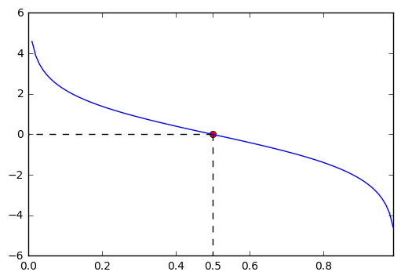

```python
x = np.linspace(0.01, 1, 100 - 1, endpoint=False)

y = np.log((1 - x) / x)

plt.xticks(list(plt.xticks()[0]) + [0.5])
plt.plot(0.5, 0, 'or')
plt.plot((0.5, 0.5), (0, -6), 'k--')
plt.plot((0.5, 0), (0, 0), 'k--')
plt.plot(x, y)
```

- We see that if the classifier has a 0.5 error rate, which is equal to random guessing, gets a weight of 0.
- If a classifier has an error rate that approaches 1, it gets a negative weight, therefore it is penalized.
- If a classifier has an error rate that approaches 0, it gets a large positive weight.
- Let's see AdaBoost in action, using the `AdaBoostClassifier` class on the heart data.
- We'll have 100 estimators, and each one of them will be a tree with just one level.

```python
from sklearn.ensemble import AdaBoostClassifier

clf = AdaBoostClassifier(
    DecisionTreeClassifier(max_depth=1),
    n_estimators=100)
scores = cross_val_score(clf, heart_df.loc[:, 'age':'thal'], heart_df['disease'])
scores.mean()
```

```
0.78062049062049066
```

# Boosting Example: Boston

- As an example of boosting, we'll use the a dataset consisting of housing values in suburbs of Boston.
- The dataframe has 506 rows and 14 columns.

```python
from sklearn.datasets import load_boston
boston = load_boston()
print(boston.DESCR)
```

```
Boston House Prices dataset
===========================

Notes
------
Data Set Characteristics:

    :Number of Instances: 506

    :Number of Attributes: 13 numeric/categorical predictive

    :Median Value (attribute 14) is usually the target

    :Attribute Information (in order):
        - CRIM     per capita crime rate by town
        - ZN       proportion of residential land zoned for lots over 25,000 sq.ft.
        - INDUS    proportion of non-retail business acres per town
        - CHAS     Charles River dummy variable (= 1 if tract bounds river; 0 otherwise)
        - NOX      nitric oxides concentration (parts per 10 million)
        - RM       average number of rooms per dwelling
        - AGE      proportion of owner-occupied units built prior to 1940
        - DIS      weighted distances to five Boston employment centres
        - RAD      index of accessibility to radial highways
        - TAX      full-value property-tax rate per $10,000
        - PTRATIO  pupil-teacher ratio by town
        - B        1000(Bk - 0.63)^2 where Bk is the proportion of blacks by town
        - LSTAT    % lower status of the population
        - MEDV     Median value of owner-occupied homes in $1000's

    :Missing Attribute Values: None

    :Creator: Harrison, D. and Rubinfeld, D.L.

This is a copy of UCI ML housing dataset.
http://archive.ics.uci.edu/ml/datasets/Housing


This dataset was taken from the StatLib library which is maintained at Carnegie Mellon University.

The Boston house-price data of Harrison, D. and Rubinfeld, D.L. 'Hedonic
prices and the demand for clean air', J. Environ. Economics & Management,
vol.5, 81-102, 1978.   Used in Belsley, Kuh & Welsch, 'Regression diagnostics
...', Wiley, 1980.   N.B. Various transformations are used in the table on
pages 244-261 of the latter.

The Boston house-price data has been used in many machine learning papers that address regression
problems.

**References**

   - Belsley, Kuh & Welsch, 'Regression diagnostics: Identifying Influential Data and Sources of Collinearity', Wiley, 1980. 244-261.
   - Quinlan,R. (1993). Combining Instance-Based and Model-Based Learning. In Proceedings on the Tenth International Conference of Machine Learning, 236-243, University of Massachusetts, Amherst. Morgan Kaufmann.
   - many more! (see http://archive.ics.uci.edu/ml/datasets/Housing)
```

- Since we are dealing with a regression problem, we will use the `AdaBoostRegressor` class.
- We will use 5000 predictors.
- We will limit the depth of each predictor to 4.

```python
from sklearn.ensemble import AdaBoostRegressor
from sklearn.tree import DecisionTreeRegressor

clf = DecisionTreeRegressor(max_depth=4)
rgr = AdaBoostRegressor(clf, n_estimators=5000)
```

- For testing the regression, we can use `train_test_split` to separate a part of the data for training and testing.
- Suppose we keep half of the data for training and half of the data for testing.
- Then the `score()` method will return the $R^2$ value of the regression.

```python
from sklearn.model_selection import train_test_split

X_train, X_test, y_train, y_test = train_test_split(boston.data, boston.target, test_size=0.50)
rgr.fit(X_train, y_train)
rgr.score(X_test, y_test)
```

```
0.77808603518315089
```

- Then we can use the MSE (mean squared error) to see how much off we are in our estimates.

```python
predicted = rgr.predict(X_test)
np.mean(np.square(predicted - y_test))
```

```
15.281323612139751
```

- That means that the actual value will be around $4000 from the true value.
- Alternatively, we could use K-folds validation.
- We will evaluate the regression with the mean squared error.
- Note that scikit-learn uses the corresponding loss function, `neg_mean_squared_error`, so we need to negate it.

```python
scores = -cross_val_score(rgr, boston.data, boston.target, cv=10, scoring="neg_mean_squared_error")
print(scores)
print(scores.mean())
```

```
[  9.55980163   5.06763583   3.11762725  20.28065362  12.76331305
  38.32468988  11.41558077  87.97983359  22.00715596  15.58801368]
22.6104305268
```

- So, the expected MSE is less than 23.
- That means that when we predict the value of a property, the expected error will be less that its square root:

```python
np.sqrt(scores.mean())
```

```
4.7550426419502676
```

- That means that the actual value will be around $5000 from the true value.
- Finally, we can obtain an overall summary of the importance of each predictor.

```
1. feature 12 LSTAT (0.390354)
2. feature 5 RM (0.233782)
3. feature 7 DIS (0.119547)
4. feature 9 TAX (0.054079)
5. feature 10 PTRATIO (0.048707)
6. feature 4 NOX (0.045207)
7. feature 0 CRIM (0.039602)
8. feature 8 RAD (0.023475)
9. feature 11 B (0.021505)
10. feature 6 AGE (0.011423)
11. feature 2 INDUS (0.009340)
12. feature 1 ZN (0.001824)
13. feature 3 CHAS (0.001156)
```

```
(-1, 13)
```

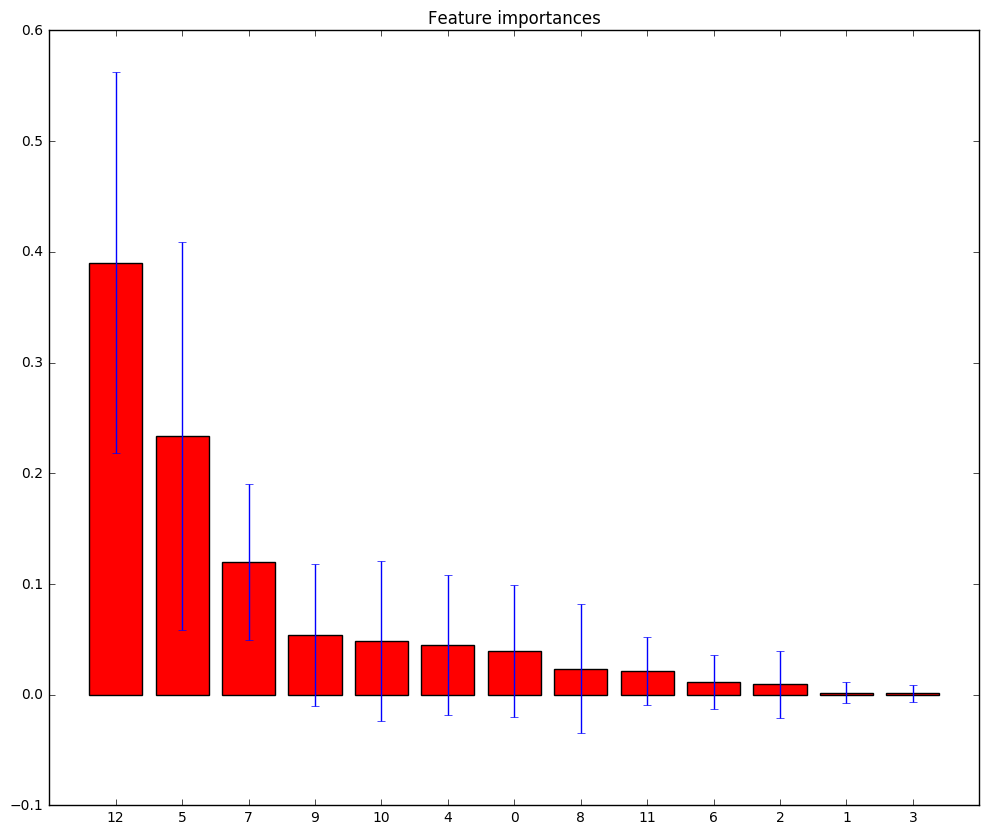

```python
rgr.fit(boston.data, boston.target)

importances = rgr.feature_importances_

std = np.std([tree.feature_importances_ for tree in rgr.estimators_],
             axis=0)
indices = np.argsort(importances)[::-1]

for f in range(boston.data.shape[1]):
    print("%d. feature %d %s (%f)" % (f + 1, indices[f], boston.feature_names[indices[f]],
                                      importances[indices[f]]))

# Plot the feature importances of the forest
plt.figure(figsize=(12, 10))
plt.title("Feature importances")
plt.bar(range(X.shape[1]), importances[indices],
       color="r", yerr=std[indices], align="center")
plt.xticks(range(X.shape[1]), indices)
plt.xlim([-1, X.shape[1]])
```